# Simulation Summary

2024-04-15

# Data Generation

We generate a simple dataset to test the ability of the model to discover unique motifs, categorize motifs as unicasting, bicasting, or multicasting, and detect differences in mice.

```r
M = 4 # number of mice
n = c(400,240, 200, 300) # number of neurons
R = 3 # number of regions
J = 2 + 4 + 1 #number of motifs (unicasting, bicasting, multicasting)

# Projection motifs
q = matrix(0,J, R)
q[1,] = c(1,0,0)
q[2,] = c(0,0,1)
# bicasting to regions 1 and 2 but with different strengths (combined in binomial)
q[3,] = c(.8,.2,0)
q[4,] = c(.3,.7,0)
# bicasting to regions 3 and 2 but with different strengths (combined in binomial)
q[5,] = c(0,.2,.8)
q[6,] = c(0,.7,0.3)
# multicast
q[7,] = c(0.3,0.4,0.3)

# Dispersion
gamma_star = matrix(50,J, 1)

# Mouse proportions (no difference between 2 and 3, but 1 and 4 are different)
w = matrix(0, J, M)
w[,1] = c(.3,0,.3,.2,0,.1,0.1)
w[,2] = c(0.05,.05,.1,.2,.1,.2,.3)
w[,3] = c(0.05,.05,.1,.2,.1,.2,.3)
w[,4] = c(0,.3,0,.1,.3,.2,0.1)

library(rBeta2009)

rdirichlet_sparse = function(n,a){
  K = length(a)
  ind = a>0
  p = matrix(0, n, K)
  if(sum(ind)>1){
    p[,ind] = rdirichlet(n,a[ind])
    if(sum(ind)==2){
      p[,which(ind)[2]] = 1- p[,which(ind)[2]]}
  }else{
    p[,ind]=1
  }
  return(p)
}

# Simulate allocations and counts
Z = list(M)
Y = list(M)
N = list(M)
for (m in c(1:M)){
  Z[[m]] =  apply(rmultinom(n[m],1, w[,m]),2,which.max)
  Y[[m]] = matrix(0,n[m],R)
  N[[m]] = floor(runif(n[m],50,201))
  for (j in c(1:J)){
    njm = sum(Z[[m]]==j)
    if(njm>0){
      qtilde = rdirichlet_sparse(njm,gamma_star[j]*q[j,])
      Y[[m]][Z[[m]]==j,] = t(apply(cbind(qtilde,N[[m]][Z[[m]]==j]), 1, function(x){rmultinom(1,x[length(x)],x[-length(x)])}))
    }
  }
}
```

Let’s visualize the projection motifs: there are two unicasting, four bicasting, and and one multicasting.

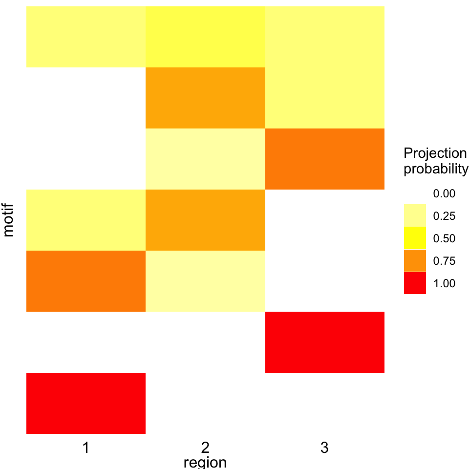

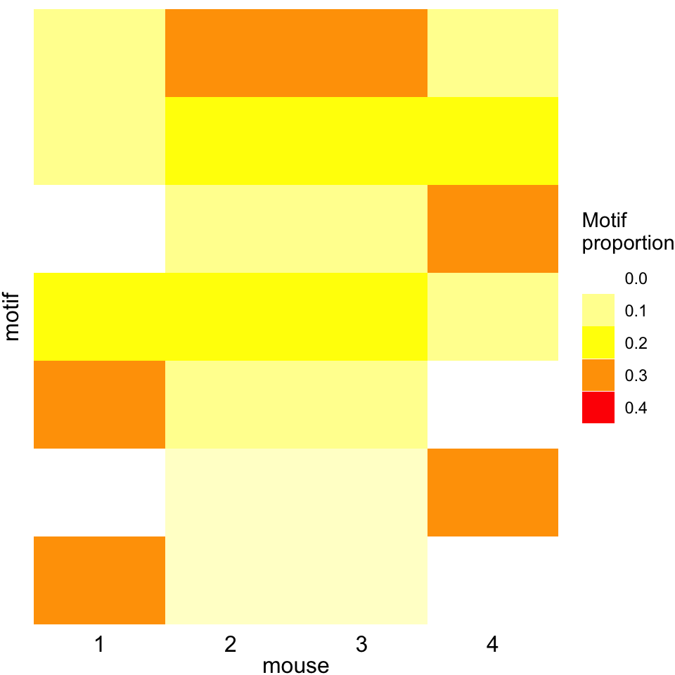

Gelplot of the simulated data; the true motifs are visible, as well as the mouse diferences.

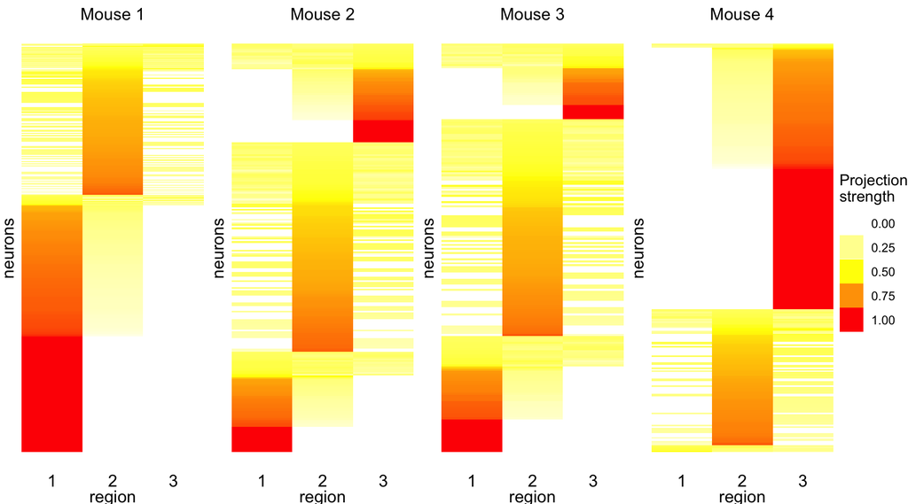

The true tv distance between the mouse-specific distributions; mouse 2 and 3 are identical, while mouse 1 and 4 have the largest difference.

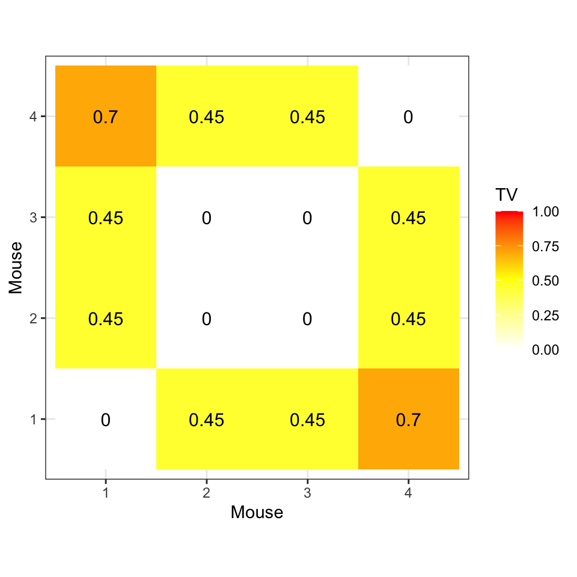

## Results

Let’s start by loading the results.

```r
load("~/Documents/GitHub/MAPseq_analysis/data/simulated/mcmc_simulated_new_largern.RData")
```

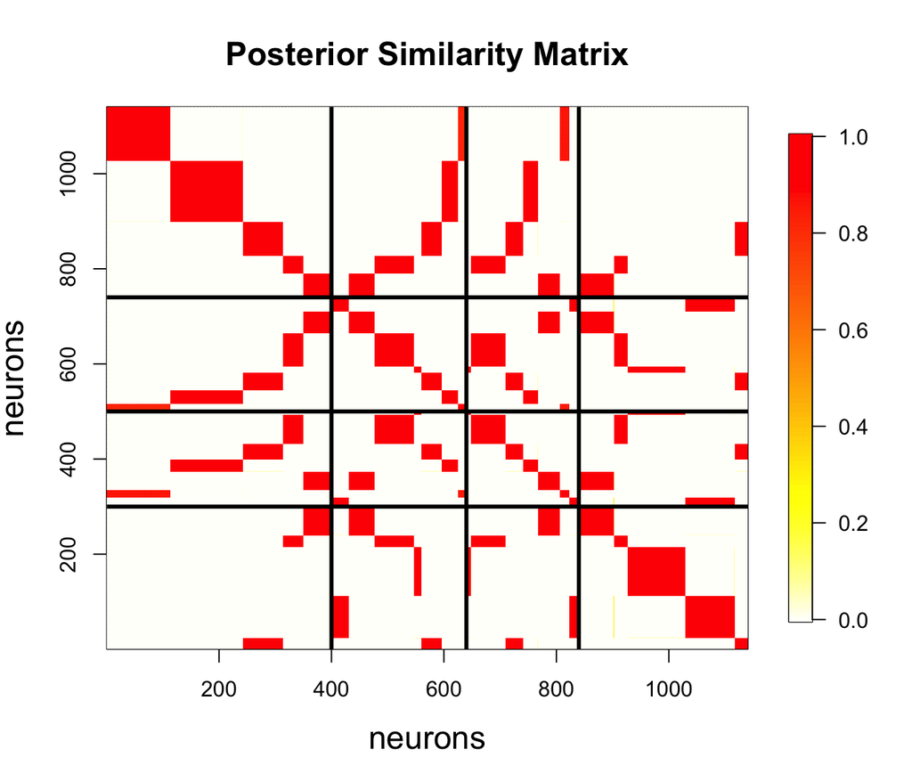

The motifs are well estimated and correctly categorized.

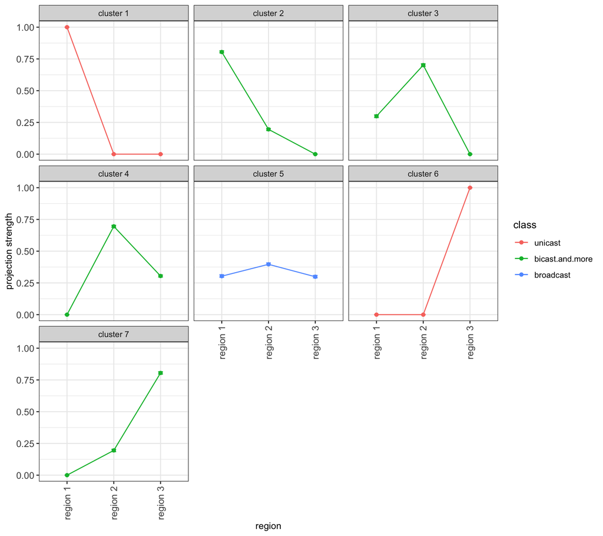

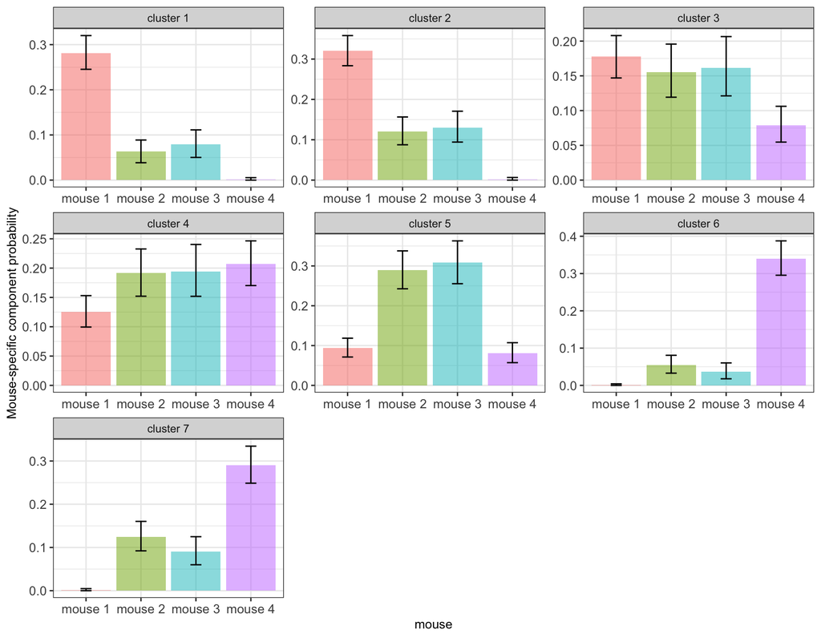

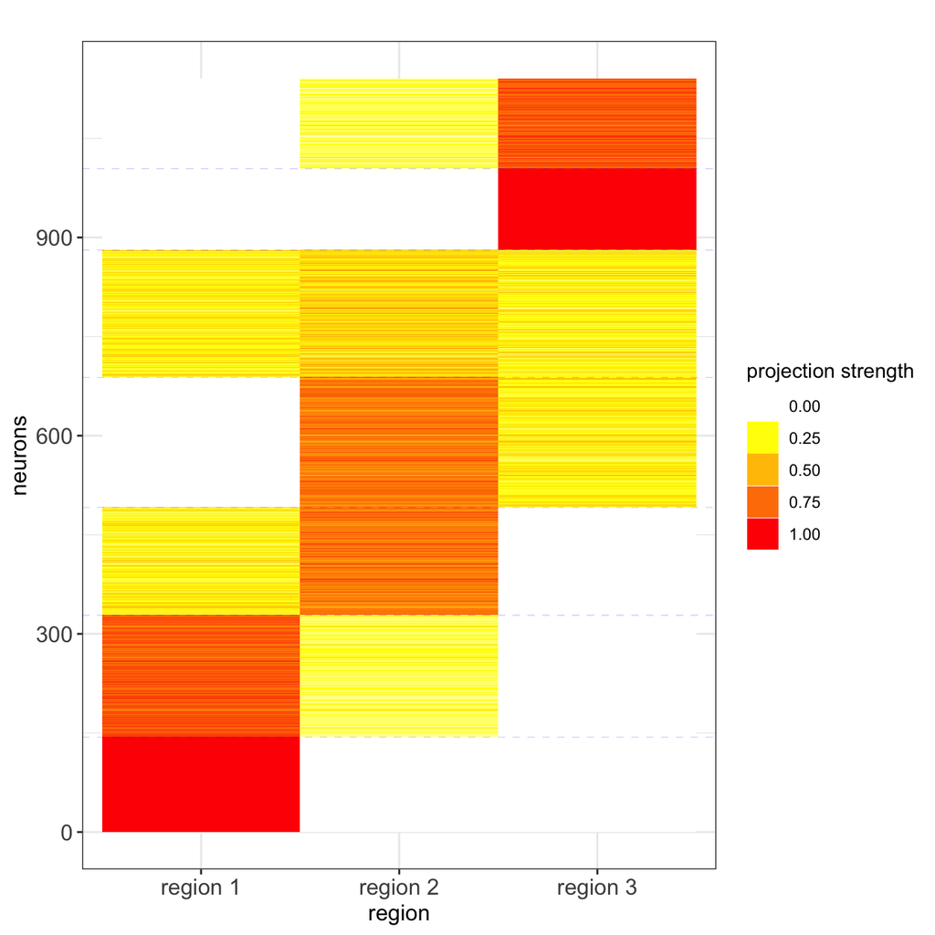

The mouse tv distances also resemble the truth.

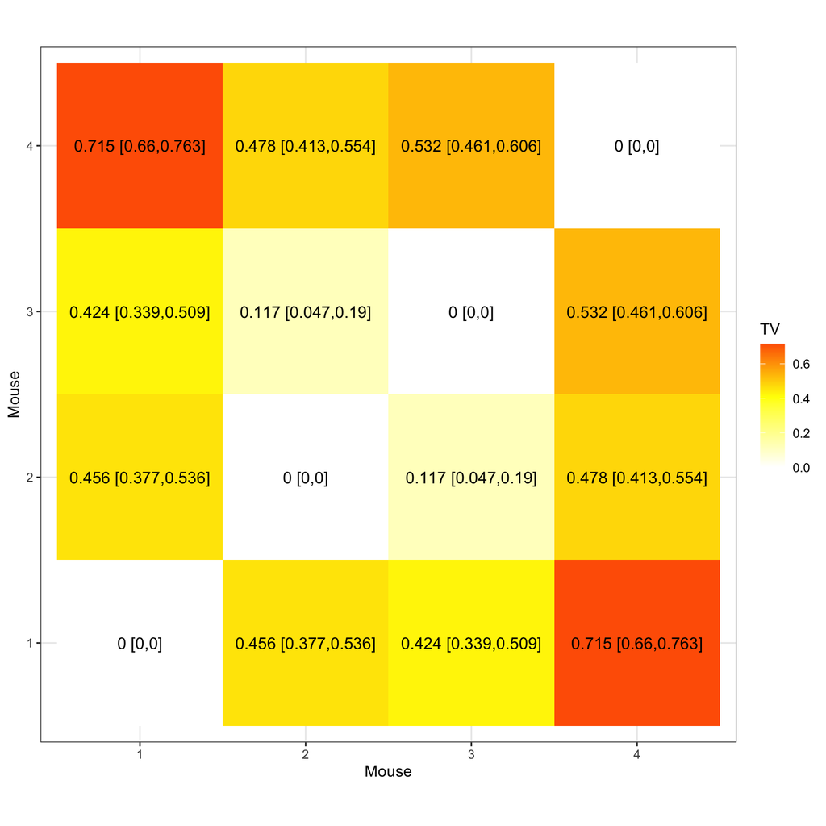

# Data Generation 2: smaller sample size

Now, let’s investigate what happens when we have less neurons per mouse. In particular, we assume the number of neurons per mouse is reduced by a factor of $1/2$.

```r
M = 4 # number of mice
n = c(200,120, 100, 150) # number of neurons
R = 3 # number of regions
J = 2 + 4 + 1 #number of motifs (unicasting, bicasting, multicasting)

# Projection motifs
q = matrix(0,J, R)
q[1,] = c(1,0,0)
q[2,] = c(0,0,1)
# bicasting to regions 1 and 2 but with different strengths (combined in binomial)
q[3,] = c(.8,.2,0)
q[4,] = c(.3,.7,0)
# bicasting to regions 3 and 2 but with different strengths (combined in binomial)
q[5,] = c(0,.2,.8)
q[6,] = c(0,.7,0.3)
# multicast
q[7,] = c(0.3,0.4,0.3)

# Dispersion
gamma_star = matrix(50,J, 1)

# Mouse proportions (no difference between 2 and 3, but 1 and 4 are different)
w = matrix(0, J, M)
w[,1] = c(.3,0,.3,.2,0,.1,0.1)
w[,2] = c(0.05,.05,.1,.2,.1,.2,.3)
w[,3] = c(0.05,.05,.1,.2,.1,.2,.3)
w[,4] = c(0,.3,0,.1,.3,.2,0.1)

library(rBeta2009)

rdirichlet_sparse = function(n,a){
  K = length(a)
  ind = a>0
  p = matrix(0, n, K)
  if(sum(ind)>1){
    p[,ind] = rdirichlet(n,a[ind])
    if(sum(ind)==2){
      p[,which(ind)[2]] = 1- p[,which(ind)[2]]}
  }else{
    p[,ind]=1
  }
  return(p)
}

# Simulate allocations and counts
Z = list(M)
Y = list(M)
N = list(M)
for (m in c(1:M)){
  Z[[m]] =  apply(rmultinom(n[m],1, w[,m]),2,which.max)
  Y[[m]] = matrix(0,n[m],R)
  N[[m]] = floor(runif(n[m],50,201))
  for (j in c(1:J)){
    njm = sum(Z[[m]]==j)
    if(njm>0){
      qtilde = rdirichlet_sparse(njm,gamma_star[j]*q[j,])
      Y[[m]][Z[[m]]==j,] = t(apply(cbind(qtilde,N[[m]][Z[[m]]==j]), 1, function(x){rmultinom(1,x[length(x)],x[-length(x)])}))
    }
  }
}
```

```r
load("~/Documents/GitHub/MAPseq_analysis/data/simulated/simulated_data.RData")
```

Let’s see the gelplot of the new data.

Gelplot of the simulated data; the true motifs are visible, as well as the mouse diferences.

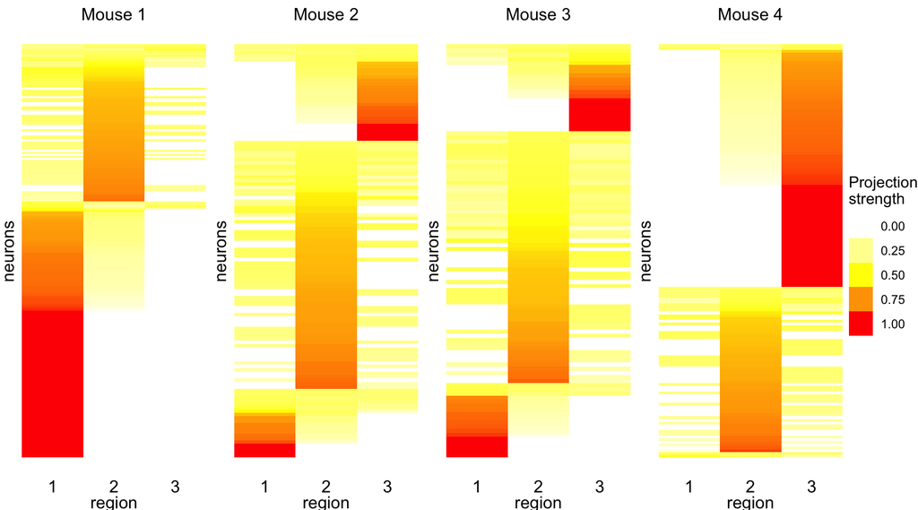

## Results

Let’s start by loading the results.

```r
load("~/Documents/GitHub/MAPseq_analysis/data/simulated/mcmc_simulated_new.RData")
```

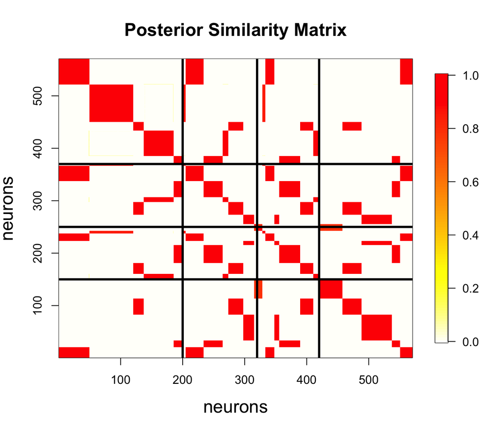

The motifs are well estimated and correctly categorized.

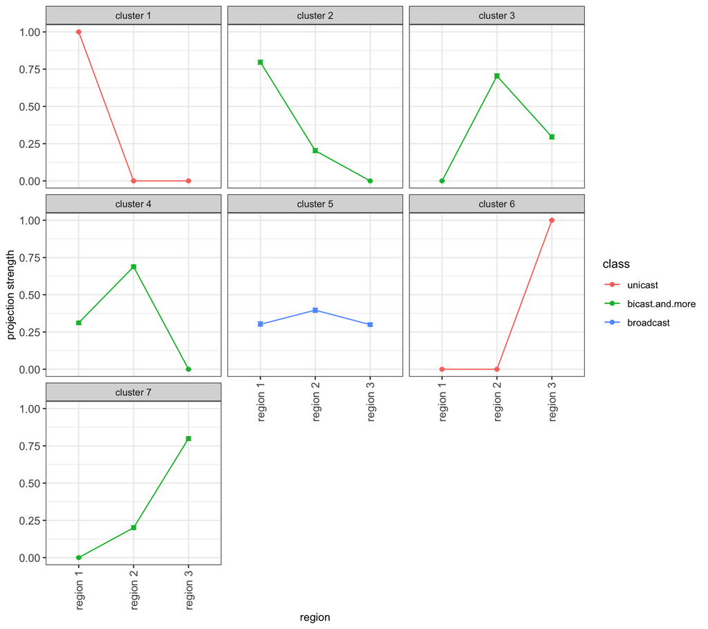

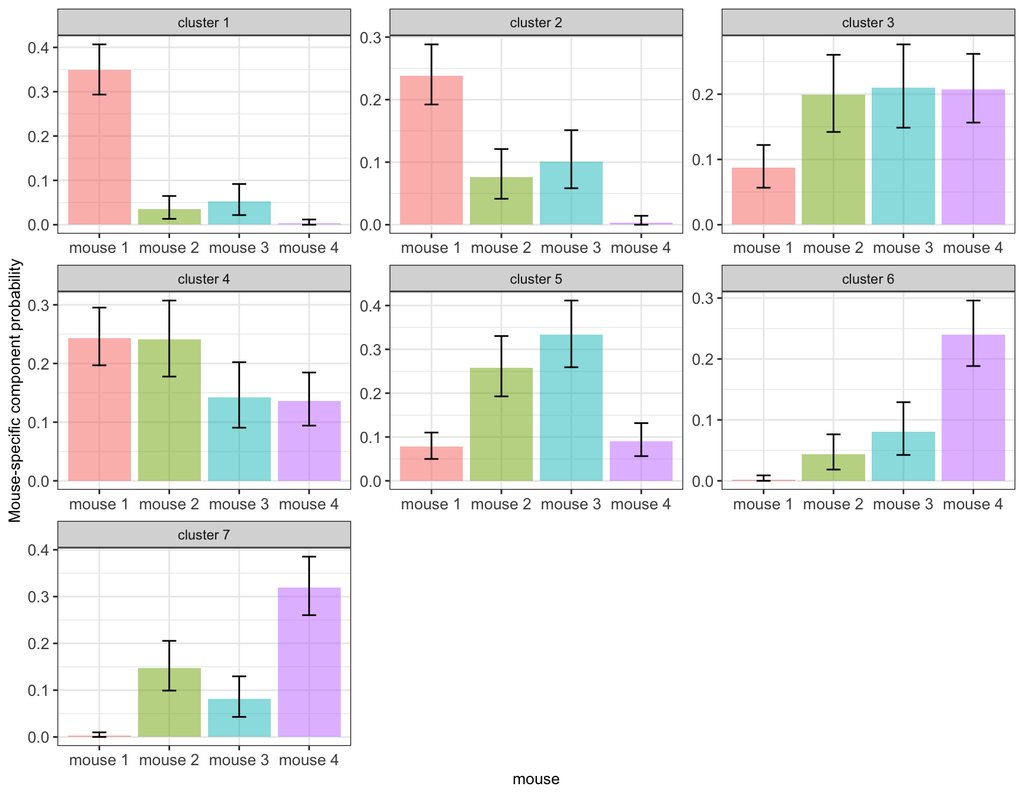

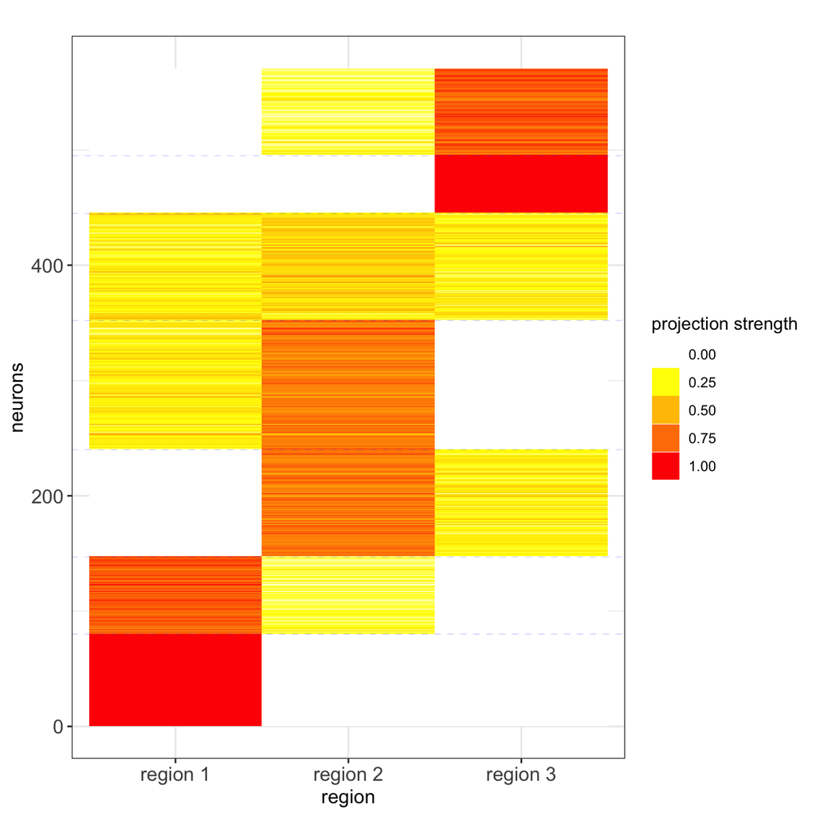

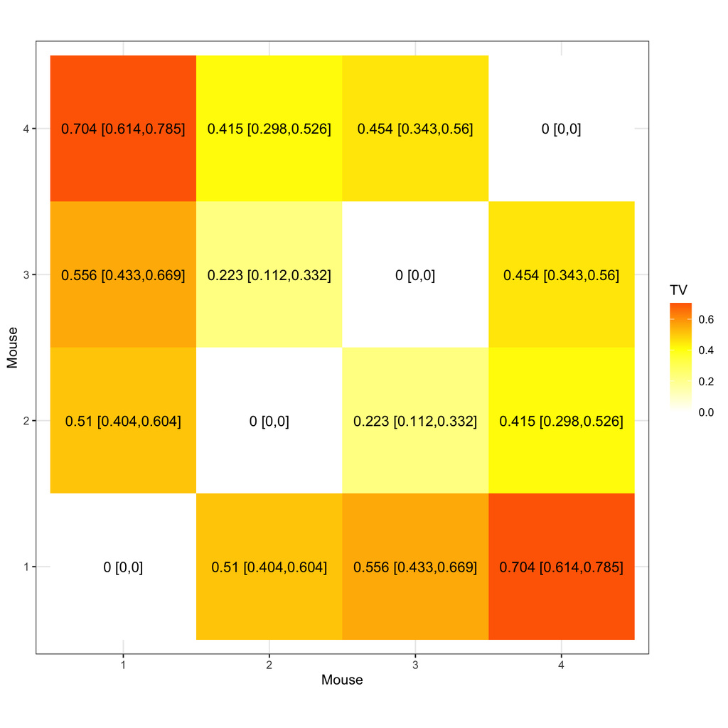

# Data Generation 3: smaller total neuron counts

```r
M = 4 # number of mice
n = c(400, 240, 200, 300) # number of neurons
R = 3 # number of regions
J = 2 + 4 + 1 #number of motifs (unicasting, bicasting, multicasting)

# Projection motifs
q = matrix(0,J, R)
q[1,] = c(1,0,0)
q[2,] = c(0,0,1)
# bicasting to regions 1 and 2 but with different strengths (combined in binomial)
q[3,] = c(.8,.2,0)
q[4,] = c(.3,.7,0)
# bicasting to regions 3 and 2 but with different strengths (combined in binomial)
q[5,] = c(0,.2,.8)
q[6,] = c(0,.7,0.3)
# multicast
q[7,] = c(0.3,0.4,0.3)

# Dispersion
gamma_star = matrix(50,J, 1)

# Mouse proportions (no difference between 2 and 3, but 1 and 4 are different)
w = matrix(0, J, M)
w[,1] = c(.3,0,.3,.2,0,.1,0.1)
w[,2] = c(0.05,.05,.1,.2,.1,.2,.3)
w[,3] = c(0.05,.05,.1,.2,.1,.2,.3)
w[,4] = c(0,.3,0,.1,.3,.2,0.1)

library(rBeta2009)

rdirichlet_sparse = function(n,a){
  K = length(a)
  ind = a>0
  p = matrix(0, n, K)
  if(sum(ind)>1){
    p[,ind] = rdirichlet(n,a[ind])
    if(sum(ind)==2){
      p[,which(ind)[2]] = 1- p[,which(ind)[2]]}
  }else{
    p[,ind]=1
  }
  return(p)
}

# Simulate allocations and counts
Z = list(M)
Y = list(M)
N = list(M)
for (m in c(1:M)){
  Z[[m]] =  apply(rmultinom(n[m],1, w[,m]),2,which.max)
  Y[[m]] = matrix(0,n[m],R)
  N[[m]] = floor(runif(n[m],5,151))
  for (j in c(1:J)){
    njm = sum(Z[[m]]==j)
    if(njm>0){
      qtilde = rdirichlet_sparse(njm,gamma_star[j]*q[j,])
      Y[[m]][Z[[m]]==j,] = t(apply(cbind(qtilde,N[[m]][Z[[m]]==j]), 1, function(x){rmultinom(1,x[length(x)],x[-length(x)])}))
    }
  }
}
```

```r
load("~/Documents/GitHub/MAPseq_analysis/data/simulated/simulated_data_largern_smallercounts.RData")
```

Let’s see the gelplot of the new data.

Gelplot of the simulated data; the true motifs are less visible, as well as the mouse diferences.

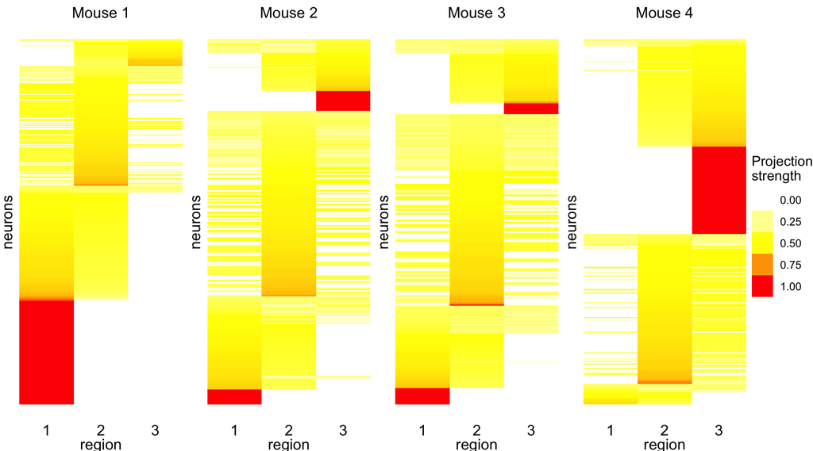

## Results

Let’s start by loading the results.

```r
load("~/Documents/GitHub/MAPseq_analysis/data/simulated/mcmc_simulated_new_largern_smallercounts.RData")
```

The posterior similarity shows more certainty in the allocation of neurons.

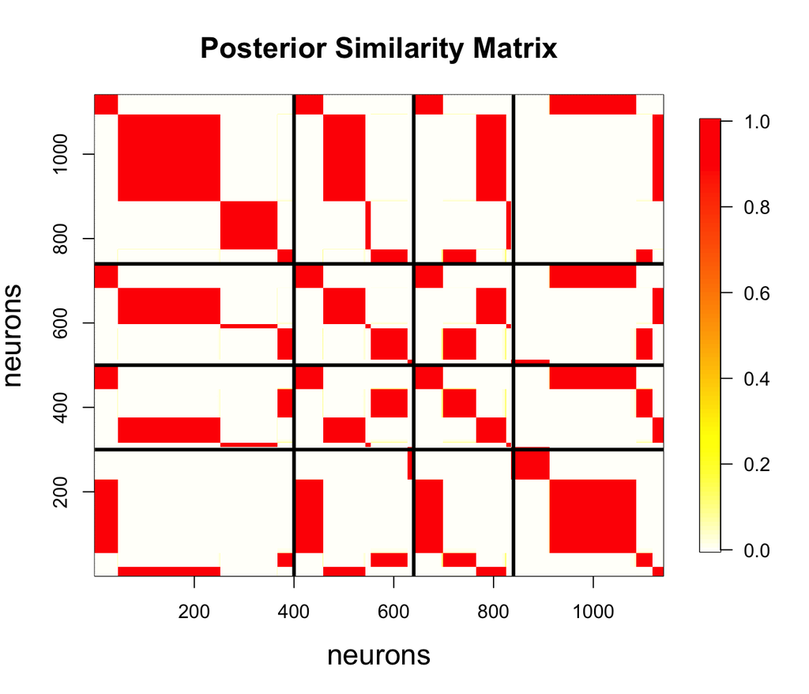

The model is not able to distingush between the four bicasting motifs, and only two are found.

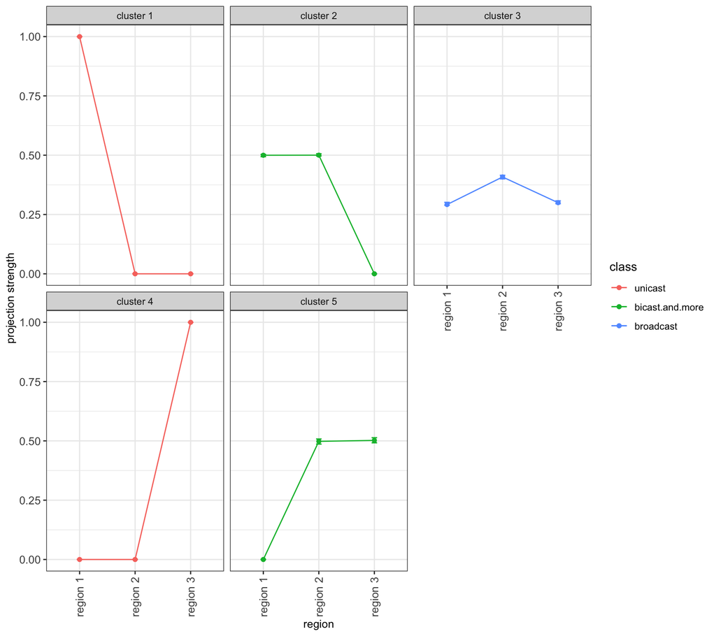

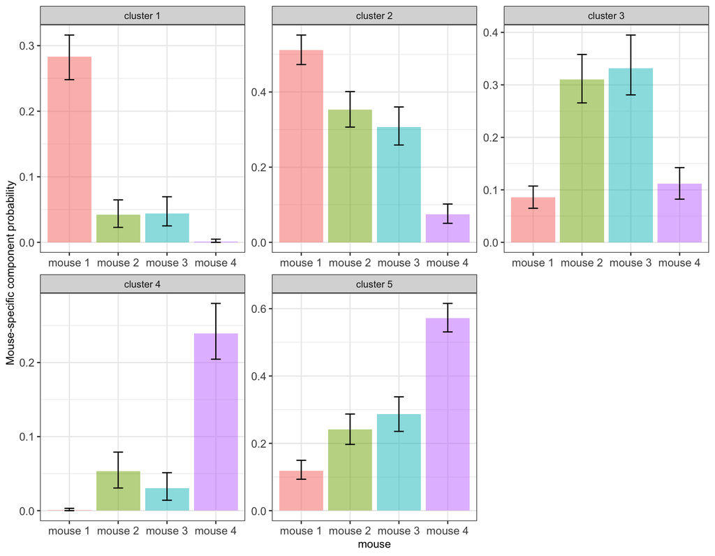

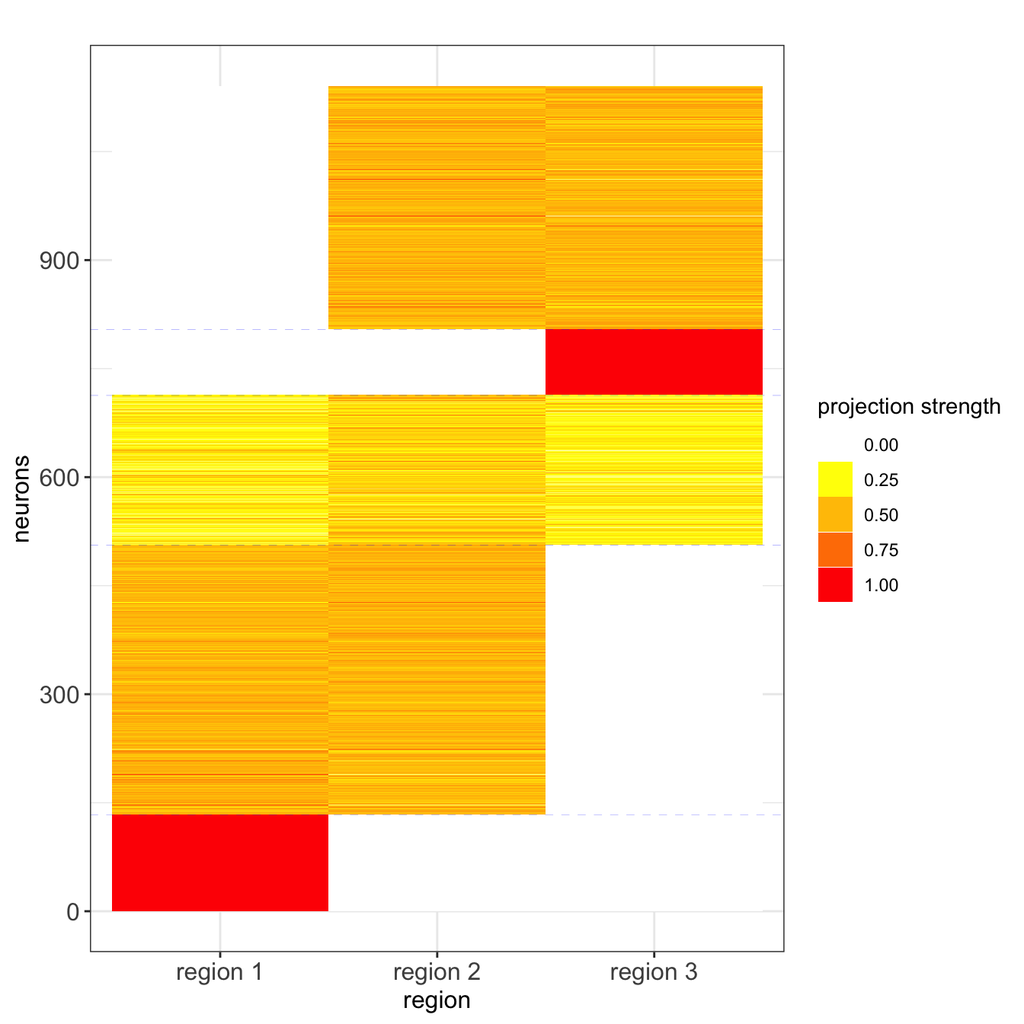

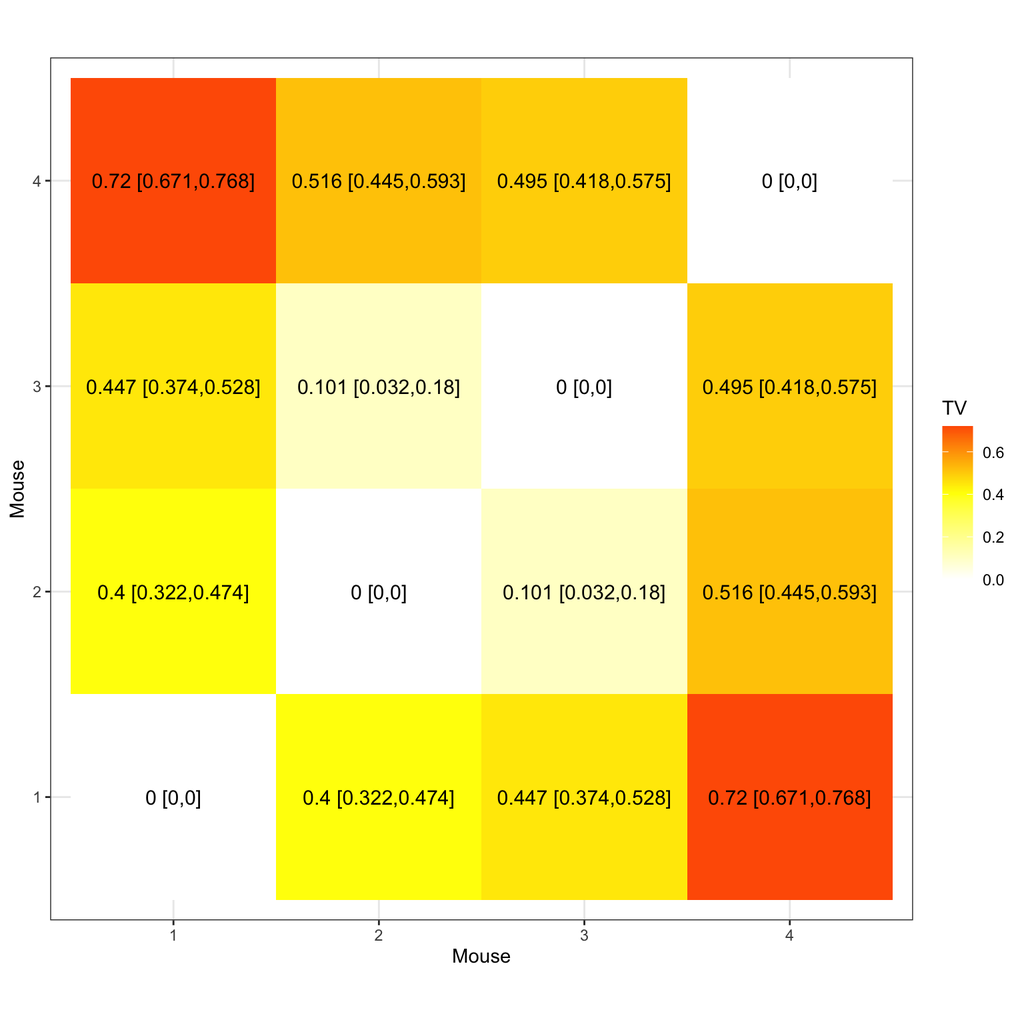